# Project: TMDb Movie Data

#### We can subject this to more analysis by checking for the correlation between both variables using a scatter plot

```python
# Defining a function to create a scatter plot

def scatter(c, df):

    # Increasing the size of the plot
    plt.subplots(figsize = (8,6))

    # Creating the scatterplot
    plt.scatter(df[c[0]], df[c[1]])

    # Adding the x, y labels and chart title
    plt.xlabel(c[2])
    plt.ylabel(c[3])
    plt.title(c[4])
```

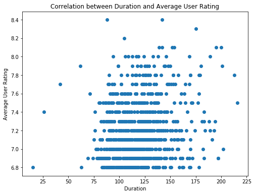

```python
scatter(['runtime','vote_average','Duration','Average User Rating','Correlation between Duration and Average User Rating'], high_votes)
```

#### Observation:

- We can see that both variables have a **weak relationship**.

#### We can confirm this by calculating it using the **corr()** function.

```python
high_votes[['runtime', 'vote_average']].corr()
```

|  | runtime | vote_average |
| --- | --- | --- |
| runtime | 1.000000 | 0.200295 |
| vote_average | 0.200295 | 1.000000 |

- The correlation between the two variables is **0.2** and that is **quite low**.
- Hence, we can say there's **weak correlation** between duration of movies and higher ratings.

### Question 3: What features are associated with generating higher revenues?

We'll be checking for the association between popularity, budget and higher revenues.

- **1. Are popular movies associated with higher revenues?**
- **2. Does higher bugdet result in generating higher revenues?**

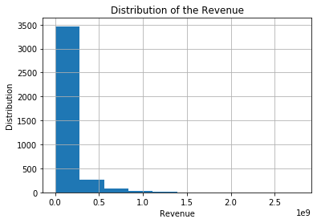

```python
# Histogram of the Revenue Column

df['revenue'].hist()
plt.xlabel('Revenue')
plt.ylabel('Distribution')
plt.title('Distribution of the Revenue');
```

#### Observation:

- The histogram of revenue shows it has a right-skewed distribution.

```python
# Descriptive Statistics of Revenue column

df['revenue'].describe()
```

```
count    3.849000e+03
mean     1.078148e+08
std      1.766175e+08
min      2.000000e+00
25%      1.367069e+07
50%      4.490726e+07
75%      1.243052e+08
max      2.781506e+09
Name: revenue, dtype: float64
```

#### Creating a dataframe that contains only High Revenue

- We'll set the higher revenue values as values greater than the 75% quantile of the revenue column.

```python
# Setting our dataframe to contain high revenue

high_rev = df.query('revenue > revenue.quantile(.75)')
high_rev.head(2)
```

[output not shown]

```python
# Descriptive statistics for High Revenue

high_rev.describe()
```

|  | popularity | budget | revenue | runtime | vote_count | vote_average | release_year | budget_adj | revenue_adj |
| --- | --- | --- | --- | --- | --- | --- | --- | --- | --- |
| count | 962.000000 | 9.620000e+02 | 9.620000e+02 | 962.000000 | 962.000000 | 962.000000 | 962.000000 | 9.620000e+02 | 9.620000e+02 |
| mean | 2.325880 | 7.912546e+07 | 3.201675e+08 | 116.161123 | 1350.253638 | 6.400624 | 2003.649688 | 8.806370e+07 | 3.850240e+08 |
| std | 2.322891 | 5.580769e+07 | 2.474572e+08 | 21.469433 | 1326.840156 | 0.703669 | 9.215590 | 5.524497e+07 | 3.015705e+08 |
| min | 0.131526 | 1.500000e+04 | 1.245964e+08 | 72.000000 | 14.000000 | 4.200000 | 1961.000000 | 1.577503e+04 | 1.161215e+08 |
| 25% | 1.139221 | 3.725000e+07 | 1.660169e+08 | 100.000000 | 467.250000 | 5.900000 | 1998.000000 | 4.510358e+07 | 1.960902e+08 |
| 50% | 1.728575 | 6.800000e+07 | 2.324708e+08 | 114.000000 | 871.500000 | 6.400000 | 2006.000000 | 7.815943e+07 | 2.849364e+08 |
| 75% | 2.689566 | 1.100000e+08 | 3.685831e+08 | 129.000000 | 1760.500000 | 6.900000 | 2011.000000 | 1.210525e+08 | 4.662607e+08 |
| max | 32.985763 | 3.800000e+08 | 2.781506e+09 | 201.000000 | 9767.000000 | 8.300000 | 2015.000000 | 3.683713e+08 | 2.827124e+09 |

### I. Are popular movies associated with higher revenues?

#### Creating a Scatter plot showing the Correlation between Revenue & Popularity

- Here, we'll create a scatter plot to check for the relationship between both variables.

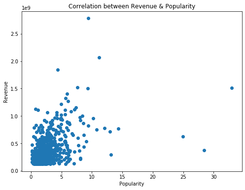

```python
# Scatter plot

scatter(['popularity','revenue','Popularity','Revenue','Correlation between Revenue & Popularity'], high_rev)
```

#### Observation:

- There's a **positive relationship** between revenue and popularity.
- It can be assumed that increase in popularity is associated with generating higher revenue.

#### Checking for the correlation between these variables using the correlation matrix

```python
# Correlation matrix

high_rev[['popularity', 'revenue']].corr()
```

|  | popularity | revenue |
| --- | --- | --- |
| popularity | 1.000000 | 0.511167 |
| revenue | 0.511167 | 1.000000 |

#### Creating a Bar Chart showing the Revenue Generated by Popularity Class.

- Here we'll create a bar chart to check the revenue generated by the different popularity class.
- The popularity will be grouped into 4 different classes depending on the quarter of percentile they belong to.

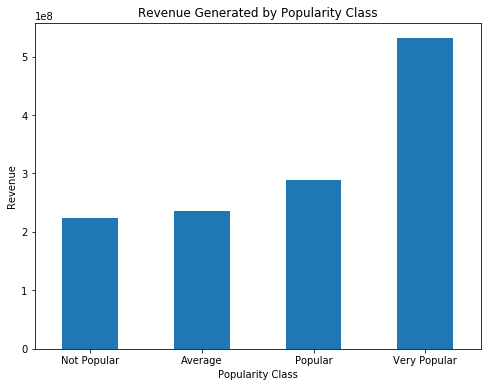

```python
# Assigning names to labels
names = ['Not Popular', 'Average', 'Popular', 'Very Popular']
label = ['Popularity Class', 'Revenue', 'Revenue Generated by Popularity Class']

# Ploting the bar chart
barchart('popularity', high_rev, names, 'revenue', label )
```

#### Observation:

- As it can be seen above; the very popular movies **contributed largely** to the higher revenues.
- We can also confirm that high popularity is associated with generating high revenues.

### II. Does higher bugdet results in generating higher revenues?

#### Creating a Scatter plot showing the Correlation between Revenue & Budget.

- Here, we'll create a scatter plot to check for the relationship between both variables.

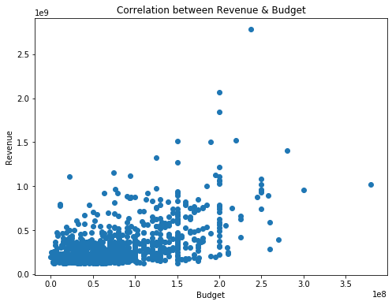

```python
# Scatter plot

scatter(['budget','revenue','Budget','Revenue','Correlation between Revenue & Budget'], high_rev)
```

#### Checking for the correlation between these variables using the correlation matrix

```python
# correlation matrix

high_rev[['budget', 'revenue']].corr()
```

|  | budget | revenue |
| --- | --- | --- |
| budget | 1.000000 | 0.556499 |
| revenue | 0.556499 | 1.000000 |

#### Creating a Bar Chart showing the Revenue Generated by Budget Class

- Here we'll create a bar chart to check the revenue generated by the different budget class.
- The budget will be grouped into 4 different classes depending on the quarter of percentile they belong to.

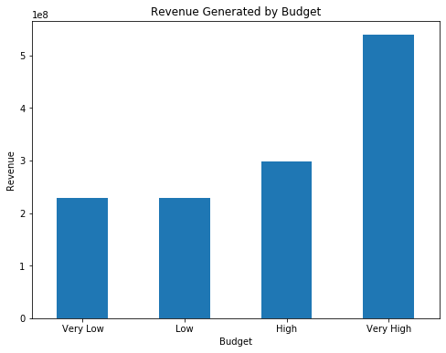

```python
# Assigning names to labels
names = ['Very Low', 'Low', 'High', 'Very High']
label = ['Budget', 'Revenue', 'Revenue Generated by Budget']

# Plotting the bar chart
barchart('budget', high_rev, names, 'revenue', label )
```

## Conclusions

#### Limitations

- At least 50% of the data for both the revenue and budget columns were dropped as they contained zeros. So this analysis was performed with a few part (only **3849 rows and 14 columns**) of the original dataset.
- Popularity and the runtime columns contained **outliers** as seen from the descriptive statistics.
- The movies has multiple values for genres, casts and directors. We kept only the first names while others were dropped.
- Hence, some of the assumptions here may not be applicable to the original dataset.